# R Notebook : For Hyper parameter optimization

*Hyper parameter optimization*

# Libraries

```r
library(pdp)
library(SOMbrero)
library(ggplot2)
library(randomForest)

#library(purrr)
library(dplyr)
library(tidyverse)
library(tidyr)
#install.packages("ggpubr")
library( ggpubr)
#remove.packages(purrr)
set.seed(2020)
```

# Feature spaces : FS1

- For SOM Brero model input feature space FS1 was extracted from the original charite.rda.
- After NA removal and splitting the Before and after treatment data two dataframes were created. FS1_data_T0 and FS1_data_T1

```r
head(FS1_data_T0)
```

| .age | tq_em | tq_co | tq_pb | tq_inti | tq_aku | tq_sl | tq_som | tq_tf | sozk_soz01_male | sozk_soz05_partner | sozk_soz10_keinAbschl | sozk_soz11_job | sozk_soz1617_arblos | sozk_soz1920_krank | sozk_soz21_tindauer | sozk_soz2224_psycho | tinskal_beein10 | tinskal_laut10 | tinskal_haeuf10 | psq_sorgen | psq_anspan | psq_freude | psq_anford | psq_psq_sum | sf8_gh_sf36ag | sf8_pf_sf36kf | sf8_rp_sf36kr | sf8_bp_sf36ks | sf8_vt_sf36vit | … |
| --- | --- | --- | --- | --- | --- | --- | --- | --- | --- | --- | --- | --- | --- | --- | --- | --- | --- | --- | --- | --- | --- | --- | --- | --- | --- | --- | --- | --- | --- | --- |
| 76 | 20 | 12 | 32 | 13 | 8 | 4 | 4 | 61 | 1 | 1 | 0 | 0 | 0 | 0.0 | 5.00 | 12.0 | 8.40 | 4.71 | 9.71 | 0.73 | 0.67 | 0.60 | 0.60 | 0.63 | 32.56 | 48.33 | 38.71 | 47.67 | 35.81 | … |
| 59 | 24 | 14 | 38 | 16 | 14 | 8 | 6 | 82 | 1 | 0 | 0 | 0 | 0 | 0.0 | 5.00 | 12.0 | 8.93 | 8.74 | 10.00 | 0.73 | 0.47 | 0.60 | 1.00 | 0.70 | 22.81 | 21.46 | 46.92 | 25.45 | 35.81 | … |
| 48 | 1 | 2 | 3 | 6 | 3 | 3 | 0 | 15 | 0 | 1 | 0 | 1 | 0 | 0.0 | 5.00 | 0.0 | 0.20 | 0.10 | 0.10 | 0.33 | 0.53 | 0.67 | 0.73 | 0.44 | 38.41 | 40.07 | 53.98 | 40.07 | 55.62 | … |
| 54 | 1 | 2 | 3 | 10 | 6 | 2 | 0 | 21 | 1 | 1 | 0 | 1 | 0 | 3.5 | 5.00 | 12.0 | 6.12 | 6.99 | 6.07 | 0.27 | 0.33 | 0.60 | 0.53 | 0.34 | 46.43 | 48.33 | 53.98 | 53.35 | 55.62 | … |
| 44 | 4 | 2 | 6 | 4 | 7 | 1 | 0 | 18 | 1 | 0 | 0 | 1 | 0 | 1.0 | 5.00 | 0.0 | 5.05 | 7.09 | 10.00 | 0.13 | 0.33 | 0.93 | 0.27 | 0.18 | 52.83 | 54.05 | 53.98 | 60.77 | 55.62 | … |
| 55 | 5 | 3 | 8 | 6 | 7 | 4 | 1 | 26 | 1 | 1 | 0 | 1 | 0 | 3.5 | 0.25 | 0.5 | 5.05 | 5.63 | 7.91 | 0.27 | 0.40 | 0.60 | 0.67 | 0.40 | 38.41 | 48.33 | 46.92 | 40.07 | 45.16 | … |

```r
#summary(FS1_data_T0)
dim(FS1_data_T0)
```

```
[1] 1743   44
```

```r
head(FS1_data_T1)
```

| .age | tq_em | tq_co | tq_pb | tq_inti | tq_aku | tq_sl | tq_som | tq_tf | sozk_soz01_male | sozk_soz05_partner | sozk_soz10_keinAbschl | sozk_soz11_job | sozk_soz1617_arblos | sozk_soz1920_krank | sozk_soz21_tindauer | sozk_soz2224_psycho | tinskal_beein10 | tinskal_laut10 | tinskal_haeuf10 | psq_sorgen | psq_anspan | psq_freude | psq_anford | psq_psq_sum | sf8_gh_sf36ag | sf8_pf_sf36kf | sf8_rp_sf36kr | sf8_bp_sf36ks | sf8_vt_sf36vit | … |
| --- | --- | --- | --- | --- | --- | --- | --- | --- | --- | --- | --- | --- | --- | --- | --- | --- | --- | --- | --- | --- | --- | --- | --- | --- | --- | --- | --- | --- | --- | --- |
| 76 | 21 | 14 | 35 | 13 | 9 | 6 | 5 | 68 | 1 | 0 | 0 | 1 | 0 | 3.5 | 5 | 12.0 | 7.77 | 7.96 | 10.00 | 0.73 | 0.60 | 0.13 | 0.60 | 0.72 | 38.41 | 30.31 | 28.32 | 40.07 | 35.81 | … |
| 59 | 23 | 10 | 33 | 15 | 10 | 8 | 6 | 72 | 0 | 1 | 1 | 0 | 0 | 0.0 | 5 | 5.5 | 9.37 | 9.85 | 9.81 | 0.87 | 0.60 | 0.40 | 0.93 | 0.78 | 22.81 | 30.31 | 28.32 | 25.45 | 35.81 | … |
| 48 | 1 | 1 | 2 | 9 | 3 | 2 | 1 | 17 | 0 | 1 | 0 | 1 | 0 | 0.0 | 5 | 0.0 | 7.33 | 8.93 | 9.42 | 0.40 | 0.40 | 0.60 | 0.60 | 0.43 | 46.43 | 40.07 | 53.98 | 31.48 | 55.62 | … |
| 54 | 15 | 6 | 21 | 13 | 10 | 5 | 2 | 51 | 1 | 1 | 0 | 0 | 0 | 3.5 | 5 | 0.0 | 8.01 | 7.33 | 10.00 | 0.60 | 0.67 | 0.33 | 0.33 | 0.52 | 38.41 | 54.05 | 46.92 | 31.48 | 45.16 | … |
| 44 | 4 | 4 | 8 | 5 | 5 | 2 | 0 | 20 | 1 | 0 | 0 | 1 | 0 | 1.0 | 5 | 0.0 | 2.09 | 3.01 | 10.00 | 0.13 | 0.33 | 0.93 | 0.33 | 0.22 | 46.43 | 48.33 | 46.92 | 60.77 | 55.62 | … |
| 55 | 3 | 3 | 6 | 3 | 4 | 1 | 0 | 14 | 1 | 1 | 0 | 1 | 0 | 3.5 | 5 | 0.0 | 4.08 | 2.77 | 9.85 | 0.27 | 0.40 | 0.67 | 0.53 | 0.37 | 38.41 | 40.07 | 53.98 | 47.67 | 45.16 | … |

```r
#summary(FS1_data_T1)
dim(FS1_data_T1)
```

```
[1] 1743   44
```

# Feature spaces : FS2

For SOM Brero model input feature space FS2 was extracted from the original charite.rda. After NA removal and splitting the Before and after treatment data two dataframes were created. FS2_data_T0 and FS2_data_T1

```r
head(FS2_data_T0)
```

| .age | tq_em | tq_co | tq_pb | tq_inti | tq_aku | tq_sl | tq_som | tq_tf | sozk_soz01_male | sozk_soz05_partner | sozk_soz10_keinAbschl | sozk_soz11_job | sozk_soz1617_arblos | sozk_soz1920_krank | sozk_soz21_tindauer | sozk_soz2224_psycho | tinskal_beein10 | tinskal_laut10 | tinskal_haeuf10 | acsa_acsa | psq_sorgen | psq_anspan | psq_freude | psq_anford | psq_psq_sum | sf8_gh_sf36ag | sf8_pf_sf36kf | sf8_rp_sf36kr | sf8_bp_sf36ks | … |
| --- | --- | --- | --- | --- | --- | --- | --- | --- | --- | --- | --- | --- | --- | --- | --- | --- | --- | --- | --- | --- | --- | --- | --- | --- | --- | --- | --- | --- | --- | --- |
| 76 | 20 | 12 | 32 | 13 | 8 | 4 | 4 | 61 | 1 | 1 | 0 | 0 | 0 | 0.0 | 5.00 | 12.0 | 8.40 | 4.71 | 9.71 | 5.8 | 0.73 | 0.67 | 0.60 | 0.60 | 0.63 | 32.56 | 48.33 | 38.71 | 47.67 | … |
| 59 | 24 | 14 | 38 | 16 | 14 | 8 | 6 | 82 | 1 | 0 | 0 | 0 | 0 | 0.0 | 5.00 | 12.0 | 8.93 | 8.74 | 10.00 | 0.3 | 0.73 | 0.47 | 0.60 | 1.00 | 0.70 | 22.81 | 21.46 | 46.92 | 25.45 | … |
| 48 | 1 | 2 | 3 | 6 | 3 | 3 | 0 | 15 | 0 | 1 | 0 | 1 | 0 | 0.0 | 5.00 | 0.0 | 0.20 | 0.10 | 0.10 | 8.1 | 0.33 | 0.53 | 0.67 | 0.73 | 0.44 | 38.41 | 40.07 | 53.98 | 40.07 | … |
| 54 | 1 | 2 | 3 | 10 | 6 | 2 | 0 | 21 | 1 | 1 | 0 | 1 | 0 | 3.5 | 5.00 | 12.0 | 6.12 | 6.99 | 6.07 | 8.5 | 0.27 | 0.33 | 0.60 | 0.53 | 0.34 | 46.43 | 48.33 | 53.98 | 53.35 | … |
| 44 | 4 | 2 | 6 | 4 | 7 | 1 | 0 | 18 | 1 | 0 | 0 | 1 | 0 | 1.0 | 5.00 | 0.0 | 5.05 | 7.09 | 10.00 | 5.1 | 0.13 | 0.33 | 0.93 | 0.27 | 0.18 | 52.83 | 54.05 | 53.98 | 60.77 | … |
| 55 | 5 | 3 | 8 | 6 | 7 | 4 | 1 | 26 | 1 | 1 | 0 | 1 | 0 | 3.5 | 0.25 | 0.5 | 5.05 | 5.63 | 7.91 | 5.6 | 0.27 | 0.40 | 0.60 | 0.67 | 0.40 | 38.41 | 48.33 | 46.92 | 40.07 | … |

```r
#summary(FS2_data_T0)
dim(FS2_data_T0)
```

```
[1] 1743   59
```

```r
head(FS2_data_T1)
```

| .age | tq_em | tq_co | tq_pb | tq_inti | tq_aku | tq_sl | tq_som | tq_tf | sozk_soz01_male | sozk_soz05_partner | sozk_soz10_keinAbschl | sozk_soz11_job | sozk_soz1617_arblos | sozk_soz1920_krank | sozk_soz21_tindauer | sozk_soz2224_psycho | tinskal_beein10 | tinskal_laut10 | tinskal_haeuf10 | acsa_acsa | psq_sorgen | psq_anspan | psq_freude | psq_anford | psq_psq_sum | sf8_gh_sf36ag | sf8_pf_sf36kf | sf8_rp_sf36kr | sf8_bp_sf36ks | … |
| --- | --- | --- | --- | --- | --- | --- | --- | --- | --- | --- | --- | --- | --- | --- | --- | --- | --- | --- | --- | --- | --- | --- | --- | --- | --- | --- | --- | --- | --- | --- |
| 76 | 21 | 14 | 35 | 13 | 9 | 6 | 5 | 68 | 0 | 1 | 0 | 0 | 0 | 0.0 | 5 | 12.0 | 7.77 | 7.96 | 10.00 | 7.3 | 0.73 | 0.60 | 0.13 | 0.60 | 0.72 | 38.41 | 30.31 | 28.32 | 40.07 | … |
| 59 | 23 | 10 | 33 | 15 | 10 | 8 | 6 | 72 | 0 | 1 | 1 | 0 | 0 | 0.0 | 5 | 5.5 | 9.37 | 9.85 | 9.81 | 9.8 | 0.87 | 0.60 | 0.40 | 0.93 | 0.78 | 22.81 | 30.31 | 28.32 | 25.45 | … |
| 48 | 1 | 1 | 2 | 9 | 3 | 2 | 1 | 17 | 0 | 1 | 0 | 1 | 0 | 0.0 | 5 | 0.0 | 7.33 | 8.93 | 9.42 | 6.6 | 0.40 | 0.40 | 0.60 | 0.60 | 0.43 | 46.43 | 40.07 | 53.98 | 31.48 | … |
| 54 | 15 | 6 | 21 | 13 | 10 | 5 | 2 | 51 | 1 | 1 | 0 | 0 | 0 | 3.5 | 5 | 0.0 | 8.01 | 7.33 | 10.00 | 3.1 | 0.60 | 0.67 | 0.33 | 0.33 | 0.52 | 38.41 | 54.05 | 46.92 | 31.48 | … |
| 44 | 4 | 4 | 8 | 5 | 5 | 2 | 0 | 20 | 1 | 0 | 0 | 1 | 0 | 1.0 | 5 | 0.0 | 2.09 | 3.01 | 10.00 | 7.6 | 0.13 | 0.33 | 0.93 | 0.33 | 0.22 | 46.43 | 48.33 | 46.92 | 60.77 | … |
| 55 | 3 | 3 | 6 | 3 | 4 | 1 | 0 | 14 | 1 | 1 | 0 | 1 | 0 | 3.5 | 5 | 0.0 | 4.08 | 2.77 | 9.85 | 5.0 | 0.27 | 0.40 | 0.67 | 0.53 | 0.37 | 38.41 | 40.07 | 53.98 | 47.67 | … |

```r
#summary(FS2_data_T1)
dim(FS2_data_T1)
```

```
[1] 1743   59
```

# Need for scaling

To standardize the ranges of the features. Scaling is important because distance between the data points is crutial .

```r
scaled_FS1_data_T0 <- scale(FS1_data_T0)
```

# Hyper Parameter combinations

Different hyper parameters of SOM Brero model were considered with respect to FS1 and FS2 data.

*Map Size*:  
* Larger map sizes result in more detailed patterns; smaller map sizes result in more general patterns (Delgado et al. 2017)  
* With proper analysis and calculation on the number of the data rows as per (Delgado et al. 2017) gave the range from [7 and 16]

*Radius Type*:  
* Two radius types are allowed in SOMBrero package.  
* This neighborhood function used to modify the weight vectors of the neighboring units’ neurons. (Liu, Suleman, and N.K. Mooers 2006)  
* Radius type guassian and letremy are mentioned in the SOM Brero package document by (Villa Vialaneix, n.d.)  
* gaussian: Gaussian neighbourhood  
* Letremy : corresponds to an piecewise linear neighbourhood

*Distance Type* :  
* During the training process the weight vector of the winner neuraon is moved towards the presented input data by a certain fraction of the Euclidean distance  
* Various distance types are allowed. All are used in the hyper parameter optimization  
* “letremy” : is the distance of the original implementation by Patrick Letremy that switches between “maximum” and “euclidean” during the training . This distance type can only be used when radius type is letremy.

*eps 0* :  
* This is scaling value used for stochastic gradient descent step in the prototypes updates.  
* Extreme ends were tested initially. Hence eps_0 ranges from [0.01 and 2]

*Prototype Initialization* :  
* Prototype for the SOM can be initialized randomly, pca or obs.  
* pca: prototypes are initialized to the observations closest to a grid along the two first principal components of the data.  
* obs: according to observations.

*Scaling* :  
* Unitvar and center is used.  
* Unitvar is for numeric data which is centered and scaled. Center is used when the input data is not scaled but only centered.  
* Korrespe was not used as it is only applicable for the contigency tables where the frequency distribution of the variables is displayed.

```r
hyper_cols <- c("h_dimension", "h_radius_type", "h_dist_type","h_maxit_var","h_eps0","h_init_proto","h_scaling")
hyper_par_df <- data.frame(matrix(ncol = length(hyper_cols),nrow = 0))
colnames(hyper_par_df) <- hyper_cols
#Combine all vectors to make one df for hypeparameter
hyper_par_df <- expand.grid(temp_dimension,temp_radius_type,temp_dist.type,temp_maxit_var,temp_eps0,temp_init.proto,temp_scaling)
colnames(hyper_par_df) <- hyper_cols
nrow(hyper_par_df) #14400 # with new dimensions 36000
```

```
[1] 36000
```

```r
head(hyper_par_df)
```

|  | h_dimension | h_radius_type | h_dist_type | h_maxit_var | h_eps0 | h_init_proto | h_scaling |
| --- | --- | --- | --- | --- | --- | --- | --- |
| 1 | 7 | gaussian | letremy | 50 | 0.01 | random | unitvar |
| 2 | 8 | gaussian | letremy | 50 | 0.01 | random | unitvar |
| 3 | 9 | gaussian | letremy | 50 | 0.01 | random | unitvar |
| 4 | 10 | gaussian | letremy | 50 | 0.01 | random | unitvar |
| 5 | 11 | gaussian | letremy | 50 | 0.01 | random | unitvar |
| 6 | 12 | gaussian | letremy | 50 | 0.01 | random | unitvar |

```r
head(hyper_par_df)
```

|  | h_dimension | h_radius_type | h_dist_type | h_maxit_var | h_eps0 | h_init_proto | h_scaling |
| --- | --- | --- | --- | --- | --- | --- | --- |
| 1 | 7 | gaussian | letremy | 50 | 0.01 | random | unitvar |
| 2 | 8 | gaussian | letremy | 50 | 0.01 | random | unitvar |
| 3 | 9 | gaussian | letremy | 50 | 0.01 | random | unitvar |
| 4 | 10 | gaussian | letremy | 50 | 0.01 | random | unitvar |
| 5 | 11 | gaussian | letremy | 50 | 0.01 | random | unitvar |
| 6 | 12 | gaussian | letremy | 50 | 0.01 | random | unitvar |

```r
nrow(hyper_par_df)
```

```
[1] 36000
```

# Hyper parameter tuning

- all 36000 hyperparameter combinations were used.
- With parallelization , total process time was 86 hours.

# Retrive the hyper parameter optimization result

```r
# Clear the old df
model_df_FS1_T0_QE<- model_df_FS1_T0_QE[0,]

#model_df_FS1_T0_QE <-read.csv("D:\\Fs1_hypertuningTotal14400.csv")
model_df_FS1_T0_QE <- read.csv("D:\\DKE\\Thesis_related\\Implementation\\Hyper_tuning_results\\Fs1_hypertuningTotal36000.csv")

head(model_df_FS1_T0_QE)
```

|  | dimension | neigh_function | distance_func | init_proto | eps_0 | TE | QE | scaling | Empty_Neurons | Max_Itr |
| --- | --- | --- | --- | --- | --- | --- | --- | --- | --- | --- |
| 1 | 7 | gaussian | euclidean | random | 0.01 | 0.9208262 | 71.37050 | unitvar | 25 | 50 |
| 2 | 8 | gaussian | euclidean | random | 0.01 | 0.9845095 | 72.25568 | unitvar | 34 | 50 |
| 3 | 9 | gaussian | euclidean | random | 0.01 | 0.9919679 | 70.02409 | unitvar | 48 | 50 |
| 4 | 10 | gaussian | euclidean | random | 0.01 | 0.9965577 | 67.92927 | unitvar | 64 | 50 |
| 5 | 11 | gaussian | euclidean | random | 0.01 | 0.9225473 | 73.61981 | unitvar | 74 | 50 |
| 6 | 12 | gaussian | euclidean | random | 0.01 | 0.9850832 | 69.10369 | unitvar | 85 | 50 |

```r
nrow(model_df_FS1_T0_QE)
```

```
[1] 36000
```

# Check all the features

```r
model_df_FS1_T0_QE  %>%
  keep(is.numeric) %>%                     # Keep only numeric columns
  gather() %>%                             # Convert to key-value pairs
  ggplot(aes(value)) +                     # Plot the values
  facet_wrap(~ key, scales = "free") +   # In separate panels
  geom_density()
```

[output not shown]

# Result of Hyper Parameter tuning

Captured “Quantization error” and " Topographic error" for all the combinations of hyper parameter.

```r
# Density graph for QE
gg_QE <- ggplot(model_df_FS1_T0_QE, aes(x = QE))
gg_QE + geom_density(aes(y = ..count..), fill = "lightgray") +
  geom_vline(aes(xintercept = mean(QE),),
             linetype = "dashed", size = 0.6,
             color = "#FC4E07")+
  geom_vline(aes(xintercept = quantile(QE)[2],),
             linetype = "dashed", size = 0.6,
             color = "blue")+
  geom_vline(aes(xintercept = quantile(QE)[4],),
             linetype = "dashed", size = 0.6,
             color = "blue")
```

[output not shown]

```r
# Density plot for TE
gg_TE <- ggplot(model_df_FS1_T0_QE, aes(x = TE))
gg_TE + geom_density(aes(y = ..count..), fill = "lightgray") +
  geom_vline(aes(xintercept = mean(TE),),
             linetype = "dashed", size = 0.6,
             color = "#FC4E07")+
  geom_vline(aes(xintercept = quantile(TE)[2],),
             linetype = "dashed", size = 0.6,
             color = "blue")+
  geom_vline(aes(xintercept = quantile(TE)[4],),
             linetype = "dashed", size = 0.6,
             color = "blue")
```

[output not shown]

```r
NA
NA
NA
NA
NA
NA
```

```r
summary(model_df_FS1_T0_QE$QE)
```

```
   Min. 1st Qu.  Median    Mean 3rd Qu.    Max.
  16.43   24.60   31.86   30.20   33.87   90.79
```

```r
summary(model_df_FS1_T0_QE$TE)
```

```
   Min. 1st Qu.  Median    Mean 3rd Qu.    Max.
0.01434 0.11991 0.32760 0.39108 0.64142 1.00000
```

# Quantization Error

- The QE is the average distance between each data vector and the BMU.(Liu, Suleman, and N.K. Mooers 2006)
- The quantization error calculates the mean squared euclidean distance between the sample vectors and their respective cluster prototypes.
- QE helps quantify the quality of the clustering.
- QE declines as the map becomes larger.(Polzlbauer, n.d.)
- Larger map sizes leads to more detailed patterns; smaller map sizes result in more general patterns.(Liu, Suleman, and N.K. Mooers 2006)
- Quantization Error can not be used to com-pare maps of different sizes. (Polzlbauer, n.d.)

# Topographic Error

- TE is the topology preservation measure.
- TE is calculated as the ratio of sample vectors for which the second best matching unit is not in the direct neighborhood of the best matching unit.(Liu, Suleman, and N.K. Mooers 2006)
- For all data samples, the respective best and second-best matching units are identified.
- If these are not adjacent on the map lattice, this is considered an error.
- TE is always normalized in the range [0,1] . (Polzlbauer, n.d.)
- 0 means topology is perserved perfectly (Polzlbauer, n.d.)
- Topographic Error is not reliable for small maps.
- TE provides an insight on the good organization on the map.

## Best Mapping quality

- Lower values of QE and TE indicate better mapping quality. (Liu, Suleman, and N.K. Mooers 2006)
- Further analysis done on the data where TE less than 0.65 and QE less than 34 . Third quartile values considered for this.

```r
#model_df_FS1_T0_QE_lower <- filter(model_df_FS1_T0_QE, model_df_FS1_T0_QE$QE<30, model_df_FS1_T0_QE$TE<0.25)

model_df_FS1_T0_QE_lower <- model_df_FS1_T0_QE[model_df_FS1_T0_QE$QE<34, ]
model_df_FS1_T0_QE_lower <- model_df_FS1_T0_QE_lower[model_df_FS1_T0_QE_lower$TE < 0.65, ]
```

```r
summary(model_df_FS1_T0_QE_lower)
```

```
   dimension      neigh_function    distance_func   init_proto       eps_0              TE                QE
 Min.   : 7.00   gaussian: 9267   canberra :3242   obs   :6116   Min.   :0.0100   Min.   :0.02811   Min.   :16.43
 1st Qu.: 9.00   letremy :10448   euclidean:4721   pca   :6447   1st Qu.:0.6733   1st Qu.:0.11933   1st Qu.:22.67
 Median :11.00                    letremy  :2282   random:7152   Median :1.1156   Median :0.22490   Median :31.09
 Mean   :11.32                    manhattan:3205                 Mean   :1.0479   Mean   :0.29898   Mean   :27.76
 3rd Qu.:14.00                    maximum  :3091                 3rd Qu.:1.5578   3rd Qu.:0.49627   3rd Qu.:32.42
 Max.   :16.00                    minkowski:3174                 Max.   :2.0000   Max.   :0.64946   Max.   :34.00
    scaling     Empty_Neurons       Max_Itr
 center :9855   Min.   :  0.00   Min.   :  50
 unitvar:9860   1st Qu.:  0.00   1st Qu.:1000
                Median :  4.00   Median :4500
                Mean   : 12.97   Mean   :4607
                3rd Qu.: 13.00   3rd Qu.:8715
                Max.   :229.00   Max.   :8715
```

```r
nrow(model_df_FS1_T0_QE_lower)
```

```
[1] 19715
```

# Partial dependence

- Need for pdp : Quantifying predictor importance.
- Partial dependence plots are used for displying marginal dependency of predictors on the target variable.
- Different packages can be used for analysing partial dependency such as pdp, iceplots.
- Even some learning models like random forest and gradient booting regressor have built in method to highlight the partial dependencies.
- PDP package visualizes the relationship between a subset of the features (max 3) and the target variable while considering the average effect of the other predictors in the model.

# Analysis of impact of hyper parameters on QE and TE

- In my thesis, PDPs will help to interpret the marginal dependency of different hyper parameters on either “Quantization Error” or “Topographic Error” ( i.e. QE or TE namely).

# Analysis of only QE

- Removed TE column in order to understand the effect of hyperparameters on QE only.

```r
# select results of hyper parameter optimization without TE
#model_df_FS1_T0_QE <- model_df_FS1_T0_QE[model_df_FS1_T0_QE$QE<100, ]
model_df_FS1_T0_QE_lower <- model_df_FS1_T0_QE_lower[,-6]
model_df_FS1_T0_QE_lower <- model_df_FS1_T0_QE_lower[,-8] # Empty neurons are not considered during pdp analysis
```

```r
nrow(model_df_FS1_T0_QE_lower)
```

```
[1] 19715
```

```r
head(model_df_FS1_T0_QE_lower)
```

|  | dimension | neigh_function | distance_func | init_proto | eps_0 | QE | scaling | Max_Itr |
| --- | --- | --- | --- | --- | --- | --- | --- | --- |
| 377 | 13 | letremy | letremy | random | 0.01 | 33.83799 | unitvar | 4500 |
| 378 | 14 | letremy | letremy | random | 0.01 | 33.44989 | unitvar | 4500 |
| 379 | 15 | letremy | letremy | random | 0.01 | 32.42716 | unitvar | 4500 |
| 380 | 16 | letremy | letremy | random | 0.01 | 32.87603 | unitvar | 4500 |
| 398 | 14 | letremy | euclidean | random | 0.01 | 33.31707 | unitvar | 4500 |
| 400 | 16 | letremy | euclidean | random | 0.01 | 33.55191 | unitvar | 4500 |

# With aggregating dimension

Results were grouped by Dimension and then partial dependence plot concept was used.

```r
#df_partial_plot_QE_FS1<- df_partial_plot_QE_FS1 %>%  select(1:7)

#head(model_df_FS1_T0_only_QE)
# Group by Dimension and QE
df_partial_plot_QE_FS1_Avg<-aggregate(x = model_df_FS1_T0_QE_lower$QE,                # Specify data column
          by = list(model_df_FS1_T0_QE_lower$dimension),              # Specify group indicator
         FUN = mean)
colnames(df_partial_plot_QE_FS1_Avg) <- c("dimension","Avg_QE")
```

```r
head(df_partial_plot_QE_FS1_Avg)
```

|  | dimension | Avg_QE |
| --- | --- | --- |
| 1 | 7 | 29.40208 |
| 2 | 8 | 28.89613 |
| 3 | 9 | 28.48409 |
| 4 | 10 | 28.00386 |
| 5 | 11 | 27.70936 |
| 6 | 12 | 27.34475 |

```r
nrow(df_partial_plot_QE_FS1_Avg)
```

```
[1] 10
```

# Partial Dependence : using random forest’s built in method

- To understand the partial dependence of the hyper parameters, random forest and pdp package was used.
- there are multiple predictors which contribute in prediction of QE.

```r
dim_avg_hyperParam.rf <- randomForest(Avg_QE ~ ., data = df_partial_plot_QE_FS1_Avg)
```

- partialPlot() method from randomForest.

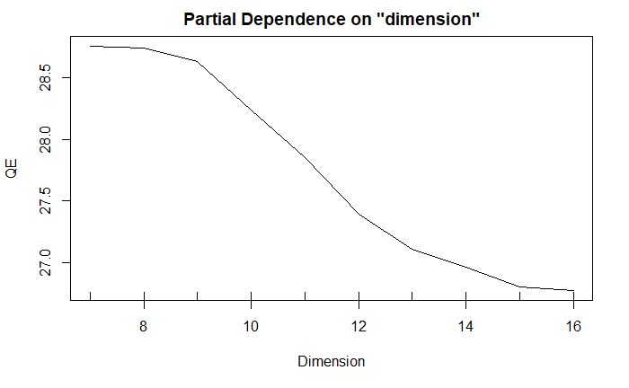

```r
partialPlot(dim_avg_hyperParam.rf, pred.data = df_partial_plot_QE_FS1_Avg, x.var = "dimension",ylab = "QE", xlab = "Dimension", theme(title = "Using randomForest's partialPlot function"))
```

```r
NA
NA
```

# Partial Dependence : Using PDP package

Conclusion: as dimension increases QE decreases.

```r
head(partial(dim_avg_hyperParam.rf, pred.var = c("dimension")))  # returns a data frame
```

|  | dimension | yhat |
| --- | --- | --- |
| 1 | 7 | 28.75968 |
| 2 | 8 | 28.74300 |
| 3 | 9 | 28.63268 |
| 4 | 10 | 28.23716 |
| 5 | 11 | 27.84940 |
| 6 | 12 | 27.39589 |

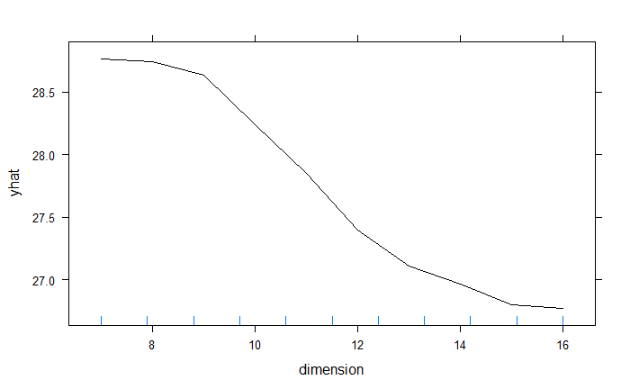

```r
partial(dim_avg_hyperParam.rf, pred.var = "dimension", plot = TRUE, rug = TRUE)
```

```r
NA
```

# Without aggregating the results of hyper parameter optimization

- PDP’s partial function helps to analyse impact of multiple predictors on target.
- Max of 3 predictors can be used for checking partial dependence.
- Below entire FS1 hyper parameter optimization results were analysed.

## Object to work with partial dependence

- To check the partial dependence random forest object created.

```r
pdp_QE_hyperParam.rf <- randomForest(QE ~ ., data = model_df_FS1_T0_QE_lower)
#,importance=TRUE ,proximity=TRUE, oob.prox=TRUE) #with these not able to allocate memory
#
```

```r
head(model_df_FS1_T0_QE_lower)
```

|  | dimension | neigh_function | distance_func | init_proto | eps_0 | QE | scaling | Max_Itr |
| --- | --- | --- | --- | --- | --- | --- | --- | --- |
| 377 | 13 | letremy | letremy | random | 0.01 | 33.83799 | unitvar | 4500 |
| 378 | 14 | letremy | letremy | random | 0.01 | 33.44989 | unitvar | 4500 |
| 379 | 15 | letremy | letremy | random | 0.01 | 32.42716 | unitvar | 4500 |
| 380 | 16 | letremy | letremy | random | 0.01 | 32.87603 | unitvar | 4500 |
| 398 | 14 | letremy | euclidean | random | 0.01 | 33.31707 | unitvar | 4500 |
| 400 | 16 | letremy | euclidean | random | 0.01 | 33.55191 | unitvar | 4500 |

```r
nrow(model_df_FS1_T0_QE_lower)
```

```
[1] 19715
```

1. PartialPlot () of random forest
- can be used only for single predictors.
- Plot one with respect to dimension shows decrease in the QE as the size increases.
- Plot 2 : QE was significantly low when “letremy” neighborhood function was selected.

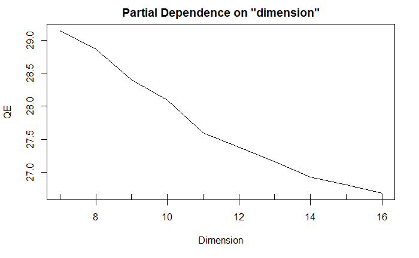

```r
partialPlot(pdp_QE_hyperParam.rf, pred.data = model_df_FS1_T0_QE_lower, x.var = "dimension",ylab = "QE", xlab = "Dimension", theme(title = "Using randomForest's partialPlot function"))
```

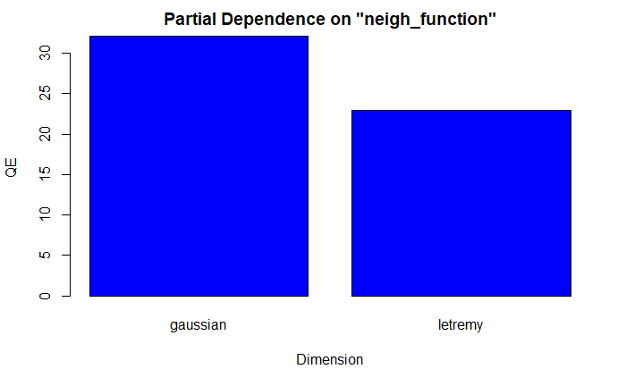

```r
partialPlot(pdp_QE_hyperParam.rf, pred.data = model_df_FS1_T0_QE_lower, x.var = "neigh_function",ylab = "QE", xlab = "Dimension", theme(title = "Using randomForest's partialPlot function"))
```

```r
NA
NA
```

2. Partial() of pdp
- since we have multiple predictors its best to use PDP package

```r
#head(partial(pdp_QE_hyperParam.rf, pred.var = c("dimension")))


p1<-partial(pdp_QE_hyperParam.rf, pred.var = c("dimension"), grid.resolution = 30,
        plot = TRUE, chull = TRUE,ylab = "QE", plot.engine = "ggplot2" , palette = "inferno")


p2<-partial(pdp_QE_hyperParam.rf, pred.var = "neigh_function",ylab = "QE", plot = TRUE, rug = TRUE,  plot.engine = "ggplot2" , palette = "inferno")

p3 <-partial(pdp_QE_hyperParam.rf, pred.var = c("dimension","neigh_function"), grid.resolution = 30,
        plot = TRUE, chull = TRUE,ylab = "QE", plot.engine = "ggplot2" , palette = "inferno")

#p4 <-partial(pdp_QE_hyperParam.rf, pred.var = c("dimension","neigh_function","init_proto"), grid.resolution = 40,
      #  plot = TRUE, chull = TRUE,ylab = "QE")
#"neigh_function","init_proto"

grid.arrange(p1, p2,p3, ncol = 2)
```

[output not shown]

3. plotPartial()
- used to plot object of Partial.
- easy to handle asthetics along with highlighting partial dependece.

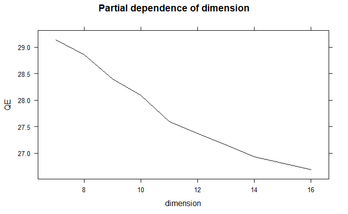

```r
p20 <-partial(pdp_QE_hyperParam.rf, pred.var = c("dimension") , grid.resolution = 40)
p21 <-partial(pdp_QE_hyperParam.rf, pred.var = c("neigh_function"), grid.resolution = 40)
p22 <-partial(pdp_QE_hyperParam.rf, pred.var = c("distance_func") , grid.resolution = 40)
p23 <-partial(pdp_QE_hyperParam.rf, pred.var = c("init_proto") , grid.resolution = 40)
p24 <-partial(pdp_QE_hyperParam.rf, pred.var = c("eps_0") , grid.resolution = 40)
p25 <-partial(pdp_QE_hyperParam.rf, pred.var = c("scaling") , grid.resolution = 40)
p26 <-partial(pdp_QE_hyperParam.rf, pred.var = c("Max_Itr") , grid.resolution = 40)


pdp_20<- plotPartial(p20,ylab="QE", main="Partial dependence of dimension" )
pdp_21<- plotPartial(p21,ylab="QE", main="Partial dependence of neighborhood function" )
pdp_22<- plotPartial(p22,ylab="QE", main="Partial dependence of distance type" )
pdp_23<- plotPartial(p23,ylab="QE", main="Partial dependence of prototype initialization" )
pdp_24<- plotPartial(p24,ylab="QE", main="Partial dependence of eps_0" )
pdp_25<- plotPartial(p25,ylab="QE", main="Partial dependence of scaling" )
pdp_26<- plotPartial(p26,ylab="QE", main="Partial dependence of max iteration" )


pdp_20
```

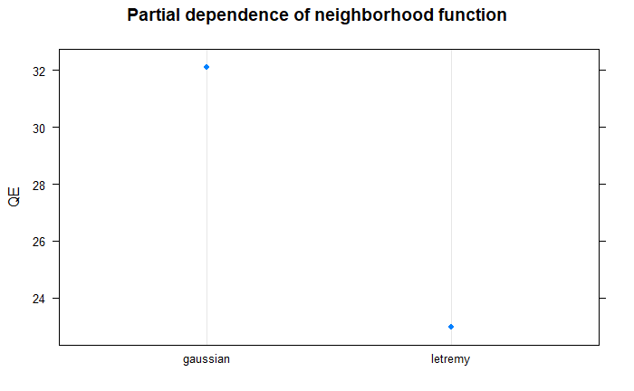

```r
pdp_21
```

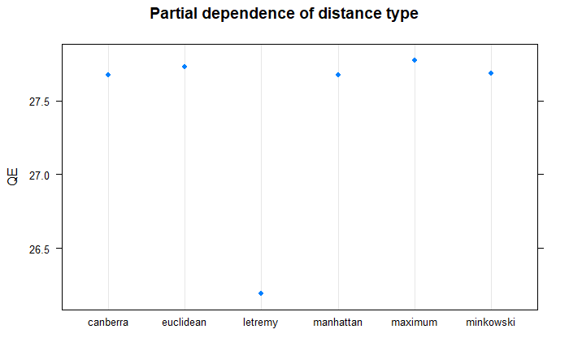

```r
pdp_22
```

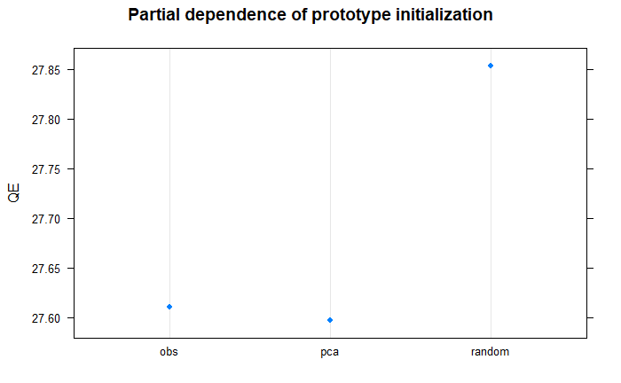

```r
pdp_23
```

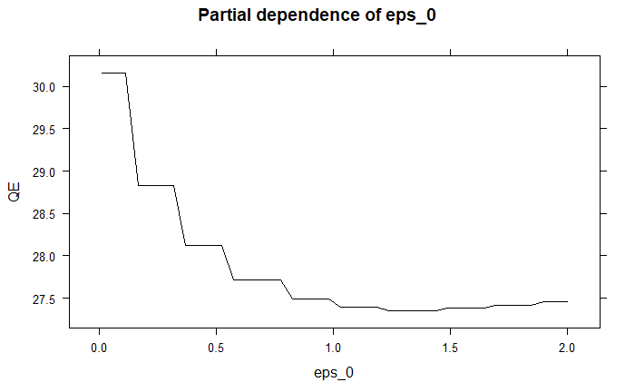

```r
pdp_24
```

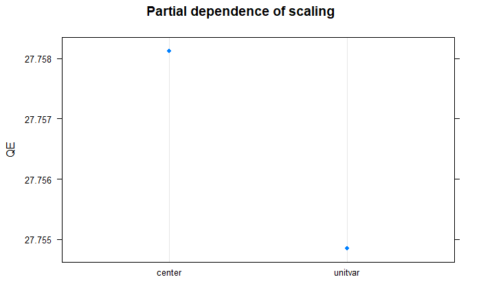

```r
pdp_25
```

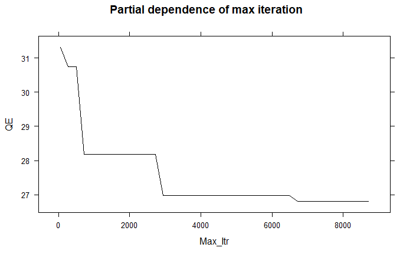

```r
pdp_26
```

```r
NA
NA
```

# Conclusion on QE (TE was not considered during this analysis)

# Some results with partial()

- yhat is QE.

```r
head(partial(pdp_QE_hyperParam.rf, pred.var = c("dimension") , grid.resolution = 40))
```

|  | dimension | yhat |
| --- | --- | --- |
| 1 | 7 | 29.14435 |
| 2 | 7 | 29.14435 |
| 3 | 7 | 29.14435 |
| 4 | 7 | 29.14435 |
| 5 | 7 | 29.14435 |
| 6 | 8 | 28.86154 |

```r
head(partial(pdp_QE_hyperParam.rf, pred.var = c("dimension","neigh_function","init_proto") , grid.resolution = 40))
```

|  | dimension | neigh_function | init_proto | yhat |
| --- | --- | --- | --- | --- |
| 1 | 7 | gaussian | obs | 32.33307 |
| 2 | 7 | gaussian | obs | 32.33307 |
| 3 | 7 | gaussian | obs | 32.33307 |
| 4 | 7 | gaussian | obs | 32.33307 |
| 5 | 7 | gaussian | obs | 32.33307 |
| 6 | 8 | gaussian | obs | 32.37039 |

```r
head(partial(pdp_QE_hyperParam.rf, pred.var = c("distance_func","init_proto","neigh_function") , grid.resolution = 40))
```

|  | distance_func | init_proto | neigh_function | yhat |
| --- | --- | --- | --- | --- |
| 1 | canberra | obs | gaussian | 32.47911 |
| 2 | euclidean | obs | gaussian | 32.47353 |
| 3 | letremy | obs | gaussian | 28.65480 |
| 4 | manhattan | obs | gaussian | 32.47470 |
| 5 | maximum | obs | gaussian | 32.66663 |
| 6 | minkowski | obs | gaussian | 32.52131 |

```r
NA
```

# Analysing impact on QE with multiple predictors

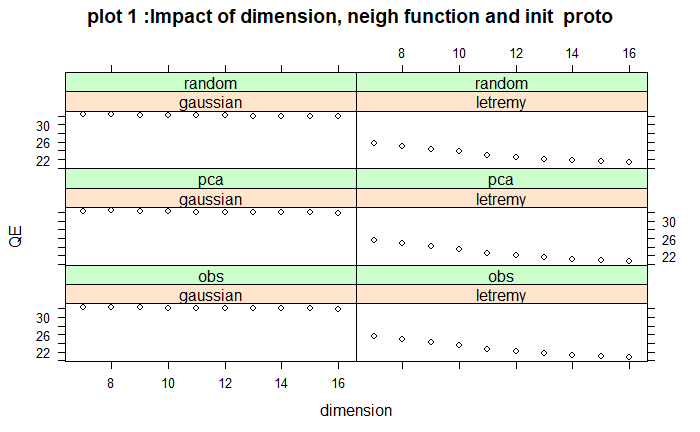

```r
p14 <-partial(pdp_QE_hyperParam.rf, pred.var = c("dimension","neigh_function","init_proto") , grid.resolution = 40)
p15 <-partial(pdp_QE_hyperParam.rf, pred.var = c("scaling","neigh_function","init_proto"), grid.resolution = 40)
p16 <-partial(pdp_QE_hyperParam.rf, pred.var = c("Max_Itr","neigh_function","init_proto"), grid.resolution = 40)


pdp_14<- plotPartial(p14,ylab="QE", main= "plot 1 :Impact of dimension, neigh function and init  proto")
pdp_15<- plotPartial(p15,ylab="QE", main= "plot 2 :Impact of scaling, neigh function and init  proto")
pdp_16<- plotPartial(p16,ylab="QE", main= "plot 3 :Impact of max itr, neigh function and init  proto")

pdp_14
```

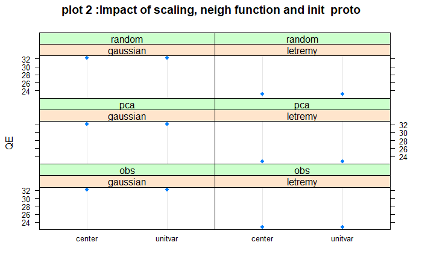

```r
pdp_15
```

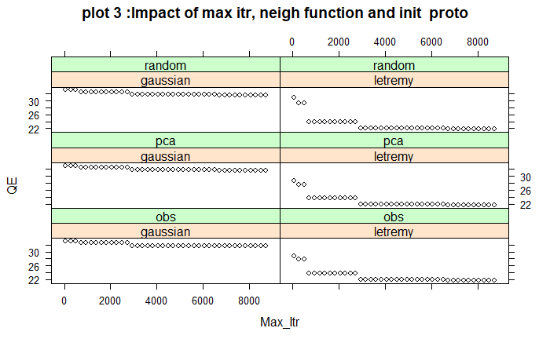

```r
pdp_16
```

```r
NA
NA
```

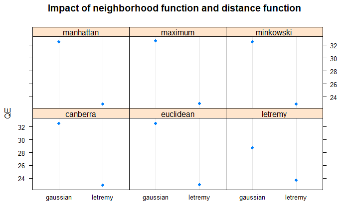

```r
#p17 <-partial(pdp_QE_hyperParam.rf, pred.var = c("init_proto","neigh_function","eps_0"), grid.resolution = 40)
#p18 <-partial(pdp_QE_hyperParam.rf, pred.var = c("init_proto","neigh_function","distance_func"), grid.resolution = 40)
p19 <-partial(pdp_QE_hyperParam.rf, pred.var = c("neigh_function","distance_func"), grid.resolution = 40)

#pdp_17<- plotPartial(p17,ylab="QE", main="Impact of Init proto, neighborhood function and eps_0")
#pdp_18<- plotPartial(p18,ylab="QE", main="Impact of Init proto, neighborhood function and distance function")
pdp_19<- plotPartial(p19,ylab="QE", main="Impact of neighborhood function and distance function")

#pdp_17
#pdp_18
pdp_19
```

- Distance type : Letremy radius along with all other distance type such as manhatten, maximum, minkowski, canberra, euclidean and letremy showed lower QE values.

# Focusing on only one dimension

- Quantization Error can not be used to com-pare maps of different sizes. (Polzlbauer, n.d.)

```r
#library(dplyr)
dim7_df <- model_df_FS1_T0_QE_lower[model_df_FS1_T0_QE_lower$dimension == 7, ]
head(dim7_df)
```

|  | dimension | neigh_function | distance_func | init_proto | eps_0 | QE | scaling | Max_Itr |
| --- | --- | --- | --- | --- | --- | --- | --- | --- |
| 731 | 7 | letremy | letremy | random | 0.2311111 | 32.76282 | unitvar | 100 |
| 771 | 7 | letremy | maximum | random | 0.2311111 | 33.76672 | unitvar | 100 |
| 791 | 7 | letremy | manhattan | random | 0.2311111 | 33.45660 | unitvar | 100 |
| 841 | 7 | gaussian | euclidean | random | 0.2311111 | 33.89584 | unitvar | 1000 |
| 851 | 7 | letremy | letremy | random | 0.2311111 | 28.49164 | unitvar | 1000 |
| 861 | 7 | gaussian | euclidean | random | 0.2311111 | 33.74766 | unitvar | 1000 |

```r
head(model_df_FS1_T0_QE_lower)
```

|  | dimension | neigh_function | distance_func | init_proto | eps_0 | QE | scaling | Max_Itr |
| --- | --- | --- | --- | --- | --- | --- | --- | --- |
| 377 | 13 | letremy | letremy | random | 0.01 | 33.83799 | unitvar | 4500 |
| 378 | 14 | letremy | letremy | random | 0.01 | 33.44989 | unitvar | 4500 |
| 379 | 15 | letremy | letremy | random | 0.01 | 32.42716 | unitvar | 4500 |
| 380 | 16 | letremy | letremy | random | 0.01 | 32.87603 | unitvar | 4500 |
| 398 | 14 | letremy | euclidean | random | 0.01 | 33.31707 | unitvar | 4500 |
| 400 | 16 | letremy | euclidean | random | 0.01 | 33.55191 | unitvar | 4500 |

```r
dim7_rf_model <- randomForest(QE~ ., data = dim7_df,importance=TRUE ,proximity=TRUE, oob.prox=TRUE)
```

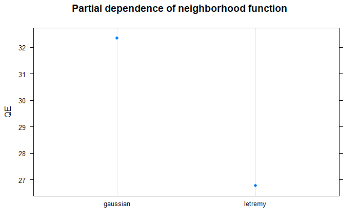

```r
p_dim7_1 <-partial(dim7_rf_model, pred.var = c("neigh_function"), grid.resolution = 40)
p_dim7_2 <-partial(dim7_rf_model, pred.var = c("distance_func") , grid.resolution = 40)
p_dim7_3 <-partial(dim7_rf_model, pred.var = c("init_proto") , grid.resolution = 40)
p_dim7_4 <-partial(dim7_rf_model, pred.var = c("eps_0") , grid.resolution = 40)
p_dim7_5 <-partial(dim7_rf_model, pred.var = c("scaling") , grid.resolution = 40)
p_dim7_6 <-partial(dim7_rf_model, pred.var = c("Max_Itr") , grid.resolution = 40)


pdp_dim7_1 <- plotPartial(p_dim7_1,ylab="QE", main="Partial dependence of neighborhood function" )
pdp_dim7_2 <- plotPartial(p_dim7_2,ylab="QE", main="Partial dependence of distance type" )
pdp_dim7_3 <- plotPartial(p_dim7_3,ylab="QE", main="Partial dependence of prototype initialization" )
pdp_dim7_4 <- plotPartial(p_dim7_4,ylab="QE", main="Partial dependence of eps_0" )
pdp_dim7_5 <- plotPartial(p_dim7_5,ylab="QE", main="Partial dependence of scaling" )
pdp_dim7_6 <- plotPartial(p_dim7_6,ylab="QE", main="Partial dependence of max iteration" )

pdp_dim7_1
```

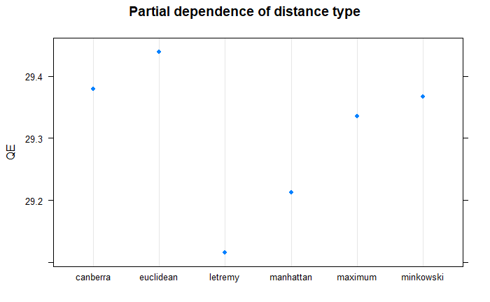

```r
pdp_dim7_2
```

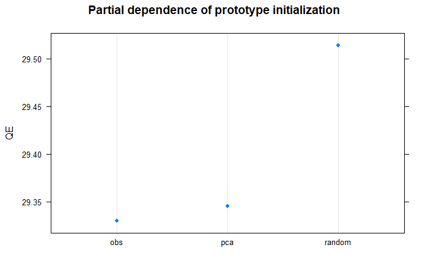

```r
pdp_dim7_3
```

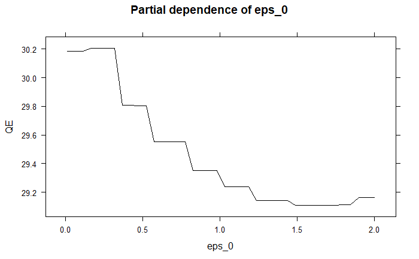

```r
pdp_dim7_4
```

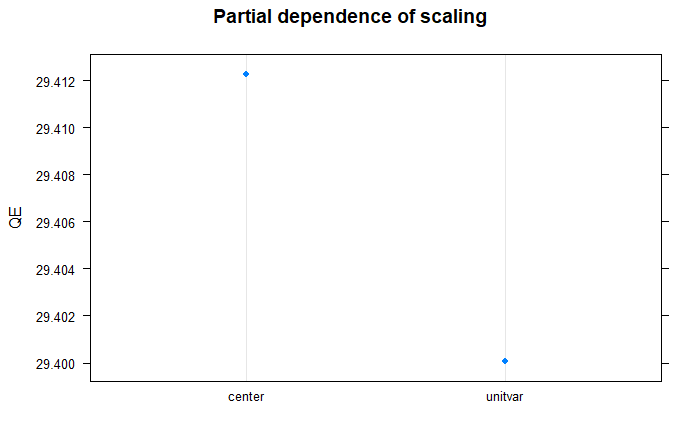

```r
pdp_dim7_5
```

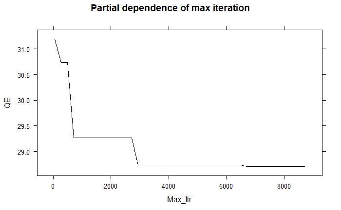

```r
pdp_dim7_6
```

# Plot Summary

only one dimension was considered here in above plots

Radius type : Letremy  
Distance type: Letremy  
Init proto : obs and pca  
eps_0 :QE decreases in between 1.5 and 1.8  
Scaling : unitvar  
Max itr: more than 6200 had low QE throughout

## Analysis of Topographic Error

```r
# original dataframe with all 36000 records
# head(model_df_FS1_T0_QE)

#head(model_df_FS1_T0_QE_lower)

model_df_FS1_T0_TE_lower <- model_df_FS1_T0_QE[model_df_FS1_T0_QE$QE<34, ]
model_df_FS1_T0_TE_lower <- model_df_FS1_T0_TE_lower[model_df_FS1_T0_TE_lower$TE < 0.65, ]

model_df_FS1_T0_TE_lower <- model_df_FS1_T0_TE_lower[,-7]
model_df_FS1_T0_TE_lower <- model_df_FS1_T0_TE_lower[,-8]

head(model_df_FS1_T0_TE_lower)
```

|  | dimension | neigh_function | distance_func | init_proto | eps_0 | TE | scaling | Max_Itr |
| --- | --- | --- | --- | --- | --- | --- | --- | --- |
| 377 | 13 | letremy | letremy | random | 0.01 | 0.4297189 | unitvar | 4500 |
| 378 | 14 | letremy | letremy | random | 0.01 | 0.3115318 | unitvar | 4500 |
| 379 | 15 | letremy | letremy | random | 0.01 | 0.3711991 | unitvar | 4500 |
| 380 | 16 | letremy | letremy | random | 0.01 | 0.3901320 | unitvar | 4500 |
| 398 | 14 | letremy | euclidean | random | 0.01 | 0.2759610 | unitvar | 4500 |
| 400 | 16 | letremy | euclidean | random | 0.01 | 0.4612737 | unitvar | 4500 |

```r
summary(model_df_FS1_T0_TE_lower)
```

```
   dimension      neigh_function    distance_func   init_proto       eps_0              TE             scaling
 Min.   : 7.00   gaussian: 9267   canberra :3242   obs   :6116   Min.   :0.0100   Min.   :0.02811   center :9855
 1st Qu.: 9.00   letremy :10448   euclidean:4721   pca   :6447   1st Qu.:0.6733   1st Qu.:0.11933   unitvar:9860
 Median :11.00                    letremy  :2282   random:7152   Median :1.1156   Median :0.22490
 Mean   :11.32                    manhattan:3205                 Mean   :1.0479   Mean   :0.29898
 3rd Qu.:14.00                    maximum  :3091                 3rd Qu.:1.5578   3rd Qu.:0.49627
 Max.   :16.00                    minkowski:3174                 Max.   :2.0000   Max.   :0.64946
    Max_Itr
 Min.   :  50
 1st Qu.:1000
 Median :4500
 Mean   :4607
 3rd Qu.:8715
 Max.   :8715
```

```r
nrow(model_df_FS1_T0_QE_lower)
```

```
[1] 19715
```

```r
nrow(model_df_FS1_T0_TE_lower)
```

```
[1] 19715
```

# Check the TE range

```r
#val_data_frame_FS1
g_FS1_T0_TE <- ggplot(model_df_FS1_T0_TE_lower, aes(x = TE))


g_FS1_T0_TE + geom_density(aes(y = ..count..), fill = "lightgray") +
  geom_vline(aes(xintercept = mean(TE),),
             linetype = "dashed", size = 0.6,
             color = "#FC4E07")
```

[output not shown]

# Partial dependence check for Topographic Error

- Using random forests partialPlot method.
- partial() and plotPartial() from PDP package are used .

```r
rf_model_TE <- randomForest(TE ~ ., data = model_df_FS1_T0_TE_lower)
#,importance=TRUE ,proximity=TRUE, oob.prox=TRUE) # need more memory
```

```r
names(model_df_FS1_T0_TE_lower)
```

```
[1] "dimension"      "neigh_function" "distance_func"  "init_proto"     "eps_0"          "TE"
[7] "scaling"        "Max_Itr"
```

# Analysis of single predictor

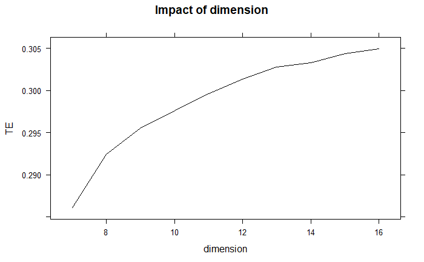

```r
p_TE_1 <-partial(rf_model_TE, pred.var = c("dimension") , grid.resolution = 40)
p_TE_2 <-partial(rf_model_TE, pred.var = c("neigh_function"), grid.resolution = 40)
p_TE_3 <-partial(rf_model_TE, pred.var = c("distance_func"), grid.resolution = 40)
p_TE_4 <-partial(rf_model_TE, pred.var = c("init_proto"), grid.resolution = 40)
p_TE_5 <-partial(rf_model_TE, pred.var = c("scaling"  ), grid.resolution = 40)
p_TE_6 <-partial(rf_model_TE, pred.var = c("Max_Itr"), grid.resolution = 40)
p_TE_7 <-partial(rf_model_TE, pred.var = c("eps_0" ), grid.resolution = 40)


pdp_TE_1<- plotPartial(p_TE_1,ylab="TE", main="Impact of dimension")
pdp_TE_2<- plotPartial(p_TE_2,ylab="TE", main="Impact of neigh_function")
pdp_TE_3<- plotPartial(p_TE_3,ylab="TE", main="Impact of distance_func")
pdp_TE_4<- plotPartial(p_TE_4,ylab="TE", main="Impact of init_proto")
pdp_TE_5<- plotPartial(p_TE_5,ylab="TE", main="Impact of scaling")
pdp_TE_6<- plotPartial(p_TE_6,ylab="TE", main="Impact of Max_Itr")
pdp_TE_7<- plotPartial(p_TE_7,ylab="TE", main="Impact of eps_0")

pdp_TE_1
```

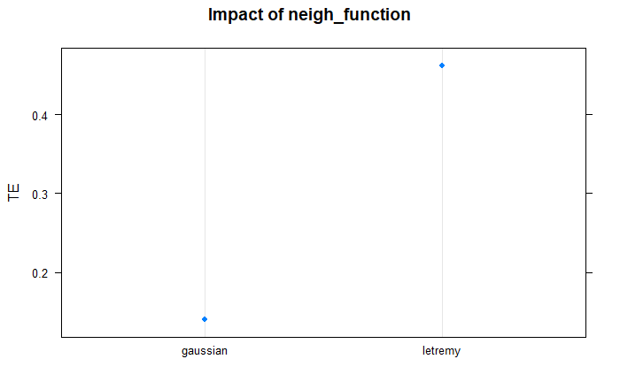

```r
pdp_TE_2
```

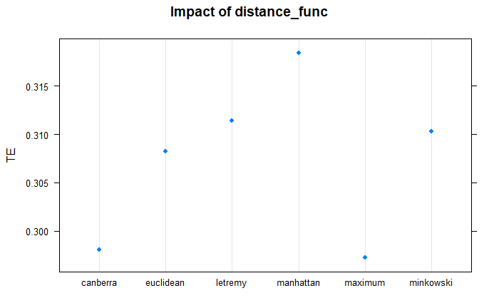

```r
pdp_TE_3
```

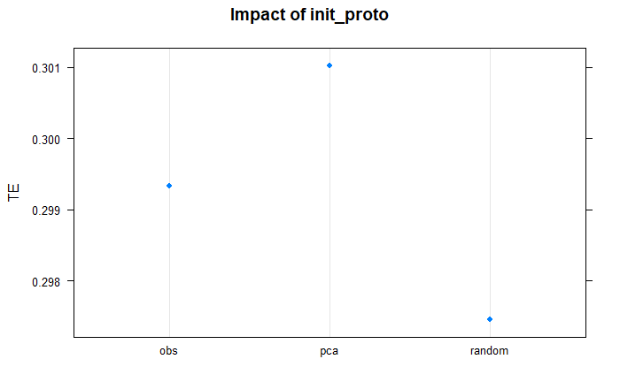

```r
pdp_TE_4
```

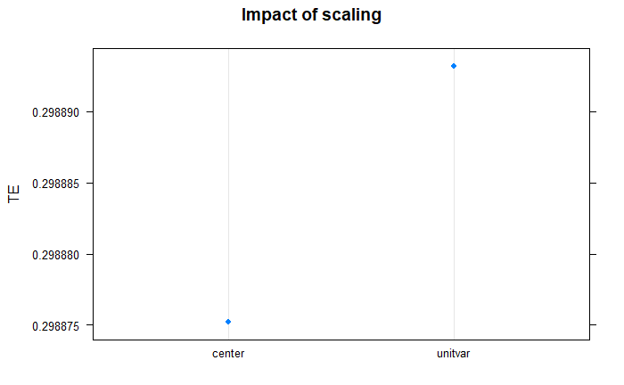

```r
pdp_TE_5
```

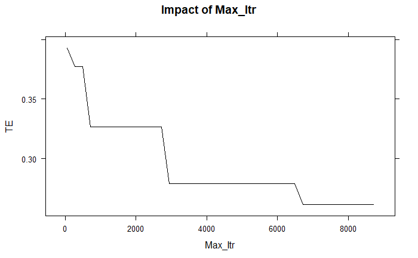

```r
pdp_TE_6
```

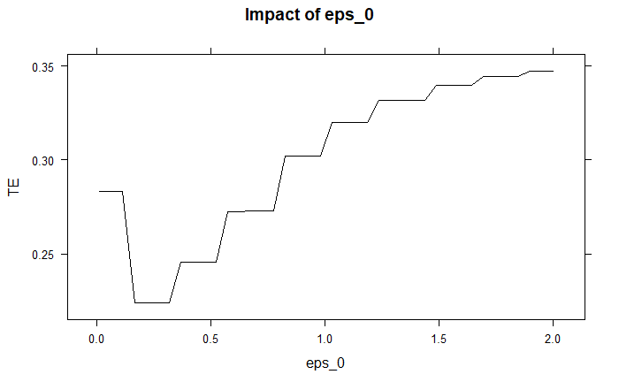

```r
pdp_TE_7
```

```r
NA
NA
```

# Summary on above plots

TE was low for below hyper parameter combination .  
* TE increases with increase in the dimension. Hence low dimensions are good for TE .  
* Neigh function : gaussian has lowest TE  
* Distance function : canberra and maximum  
* Init proto : random  
* scaling : Not significant difference. However still center had lowest TE  
* Maxt itr: more than 6500.  
* eps_0 : in between 0.2 and 0.35 approx

# Max itr and Eps lowest TE

- in dataframe retrieved from partial()

```r
p_TE_6[p_TE_6$yhat == min(p_TE_6$yhat),]
```

|  | Max_Itr | yhat |
| --- | --- | --- |
| 31 | 6715 | 0.2612039 |
| 32 | 6937 | 0.2612039 |
| 33 | 7159 | 0.2612039 |
| 34 | 7381 | 0.2612039 |
| 35 | 7604 | 0.2612039 |
| 36 | 7826 | 0.2612039 |
| 37 | 8048 | 0.2612039 |
| 38 | 8270 | 0.2612039 |
| 39 | 8492 | 0.2612039 |
| 40 | 8715 | 0.2612039 |

```r
p_TE_7[p_TE_7$yhat == min(p_TE_7$yhat),]
```

|  | eps_0 | yhat |
| --- | --- | --- |
| 6 | 0.2651282 | 0.2237156 |
| 7 | 0.3161538 | 0.2237156 |

# Analysis of multiple predictors

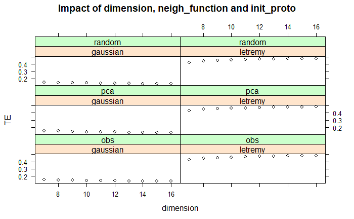

```r
p_TE_8 <-partial(rf_model_TE, pred.var = c("dimension","neigh_function","init_proto") , grid.resolution = 80)
p_TE_9 <-partial(rf_model_TE, pred.var = c("neigh_function","distance_func","init_proto"), grid.resolution = 40)
p_TE_10 <-partial(rf_model_TE, pred.var = c("neigh_function","distance_func","scaling"), grid.resolution = 40)
p_TE_11 <-partial(rf_model_TE, pred.var = c("Max_Itr","init_proto" ,"neigh_function"), grid.resolution = 40)
p_TE_12 <-partial(rf_model_TE, pred.var = c("scaling","neigh_function","init_proto" ), grid.resolution = 40)
p_TE_13 <-partial(rf_model_TE, pred.var = c("eps_0","init_proto","neigh_function"), grid.resolution = 40)
#p_TE_7 <-partial(rf_model_TE, pred.var = c("eps_0" ), grid.resolution = 40)


pdp_TE_8<- plotPartial(p_TE_8,ylab="TE", main="Impact of dimension, neigh_function and init_proto")
pdp_TE_9<- plotPartial(p_TE_9,ylab="TE", main="Impact of neigh_function, distance_func and init_proto")
pdp_TE_10<- plotPartial(p_TE_10,ylab="TE", main="Impact of neigh_function, distance_func and scaling")
pdp_TE_11<- plotPartial(p_TE_11,ylab="TE", main="Impact of   Max_Itr,init_proto and neigh_function")
pdp_TE_12<- plotPartial(p_TE_12,ylab="TE", main="Impact of scaling, neigh_function and init_proto")
pdp_TE_13<- plotPartial(p_TE_13,ylab="TE", main="Impact of eps_0, init_proto and neigh_function")
#pdp_TE_7<- plotPartial(p_TE_7,ylab="TE", main="Impact of eps_0")

pdp_TE_8
```

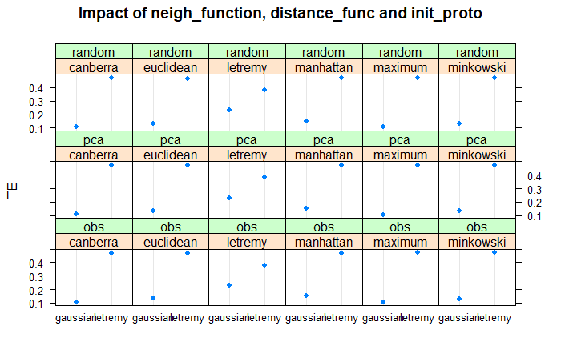

```r
pdp_TE_9
```

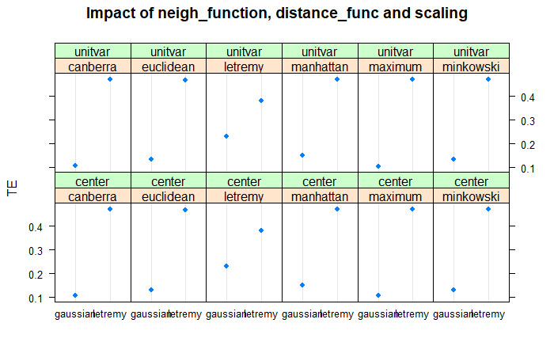

```r
pdp_TE_10
```

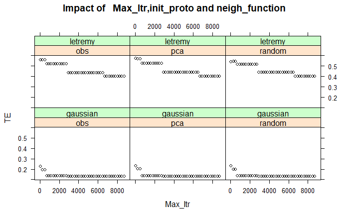

```r
pdp_TE_11
```

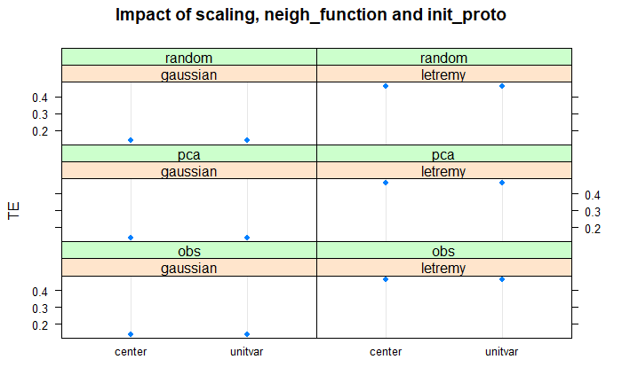

```r
pdp_TE_12
```

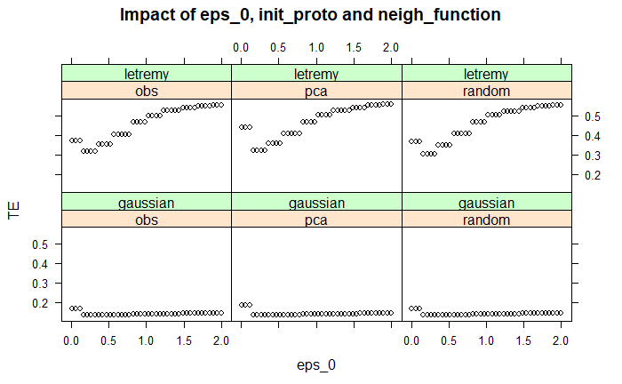

```r
pdp_TE_13
```

```r
NA
NA
NA
NA
NA
```

# Summary on above plots

TE was low for below hyper parameter combination  
* Dimension when considered along with other features does not have much impact on TE.  
* Neighborhood function :gaussian. any type of init proto, and dimension  
* Distance function gaussian along with any distance function with letremy had slighly more TE others distance type yeild low TE results  
* all graphs show guassian neigh function has more importance on TE value.

# Conclusion for TE ( QE was not considered during analysis)

## Lower QE and TE values indicate better mapping quality.

We need to find the best combination for best QE and TE

## Analysis of both QE and TE together

- TE will be the target.
- all hyper parameter along with QE will be the predictors for checking partial dependence.
- PDP package : partial() method used to understand the partial dependence.

```r
#model_df_FS1_T0_TE_QE <- model_df_FS1_T0_TE_QE[0,]
#model_df_FS1_T0_TE_QE <-read.csv("D:\\Fs1_hypertuningTotal14400.csv")
#model_df_FS1_T0_TE_QE <- model_df_FS1_T0_TE_QE[model_df_FS1_T0_TE_QE$QE<100, ]
#model_df_FS1_T0_TE_QE <- model_df_FS1_T0_TE_QE[,-9]

model_df_FS1_T0_TE_QE <- read.csv("D:\\DKE\\Thesis_related\\Implementation\\Hyper_tuning_results\\Fs1_hypertuningTotal36000.csv")

model_df_FS1_T0_TE_QE_lower <- model_df_FS1_T0_TE_QE[model_df_FS1_T0_TE_QE$QE<34, ]
model_df_FS1_T0_TE_QE_lower <- model_df_FS1_T0_TE_QE_lower[model_df_FS1_T0_TE_QE_lower$TE < 0.65, ]

head(model_df_FS1_T0_TE_QE_lower)
```

|  | dimension | neigh_function | distance_func | init_proto | eps_0 | TE | QE | scaling | Empty_Neurons | Max_Itr |
| --- | --- | --- | --- | --- | --- | --- | --- | --- | --- | --- |
| 377 | 13 | letremy | letremy | random | 0.01 | 0.4297189 | 33.83799 | unitvar | 113 | 4500 |
| 378 | 14 | letremy | letremy | random | 0.01 | 0.3115318 | 33.44989 | unitvar | 140 | 4500 |
| 379 | 15 | letremy | letremy | random | 0.01 | 0.3711991 | 32.42716 | unitvar | 159 | 4500 |
| 380 | 16 | letremy | letremy | random | 0.01 | 0.3901320 | 32.87603 | unitvar | 190 | 4500 |
| 398 | 14 | letremy | euclidean | random | 0.01 | 0.2759610 | 33.31707 | unitvar | 159 | 4500 |
| 400 | 16 | letremy | euclidean | random | 0.01 | 0.4612737 | 33.55191 | unitvar | 217 | 4500 |

```r
nrow(model_df_FS1_T0_TE_QE_lower)
```

```
[1] 19715
```

```r
names(model_df_FS1_T0_TE_QE_lower)
```

[output not shown]

```r
rf_model_target_TE <- randomForest(TE ~ ., data = model_df_FS1_T0_TE_QE_lower)
```

- only single predictors

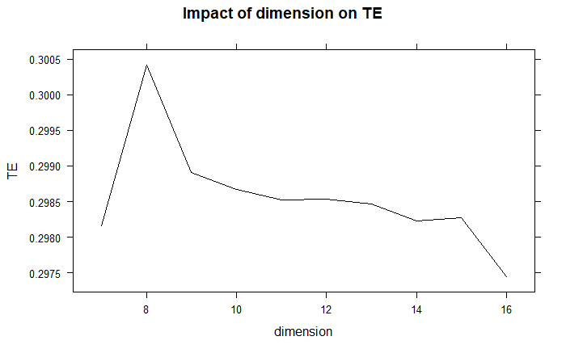

```r
p_FS1_T0_TE_QE_TE_1 <-partial(rf_model_target_TE, pred.var = c("dimension") , grid.resolution = 40 )
p_FS1_T0_TE_QE_TE_2 <-partial(rf_model_target_TE, pred.var = c("neigh_function"), grid.resolution = 40)
p_FS1_T0_TE_QE_TE_3 <-partial(rf_model_target_TE, pred.var = c("distance_func"), grid.resolution = 40)

pdp_FS1_T0_TE_QE_TE_1<- plotPartial(p_FS1_T0_TE_QE_TE_1,ylab="TE", main="Impact of dimension on TE")
pdp_FS1_T0_TE_QE_TE_2<- plotPartial(p_FS1_T0_TE_QE_TE_2,ylab="TE", main="Impact of neigh function on TE")
pdp_FS1_T0_TE_QE_TE_3<- plotPartial(p_FS1_T0_TE_QE_TE_3,ylab="TE", main="Impact of Distance function on TE")


pdp_FS1_T0_TE_QE_TE_1
```

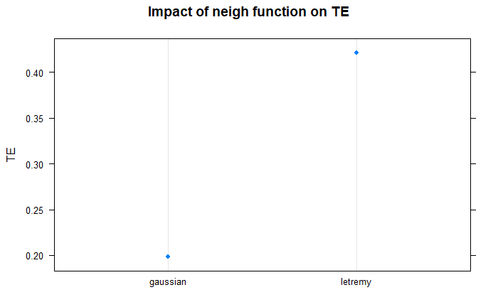

```r
pdp_FS1_T0_TE_QE_TE_2
```

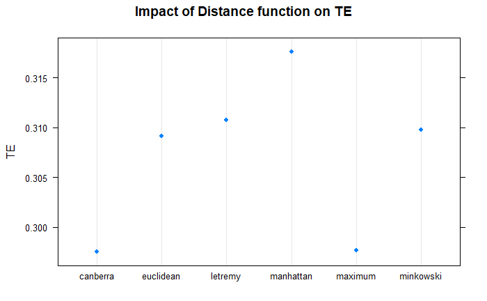

```r
pdp_FS1_T0_TE_QE_TE_3
```

```r
NA
NA
```

# Summary on graphs

TE was low when  
* Dimension was high. But difference is not that much.  
* Neigh function: guassian . Deciding factor  
* Distance: canberra and maximum had low values for TE. But difference is not much.

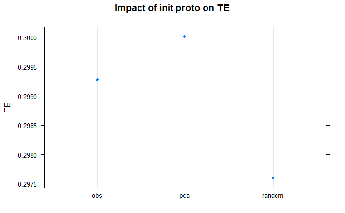

```r
p_FS1_T0_TE_QE_TE_4 <-partial(rf_model_target_TE, pred.var = c("init_proto"), grid.resolution = 40)
p_FS1_T0_TE_QE_TE_5 <-partial(rf_model_target_TE, pred.var = c("eps_0"), grid.resolution = 40)
p_FS1_T0_TE_QE_TE_6 <-partial(rf_model_target_TE, pred.var = c("QE"), grid.resolution = 40)


pdp_FS1_T0_TE_QE_TE_4<- plotPartial(p_FS1_T0_TE_QE_TE_4,ylab="TE", main="Impact of init proto on TE")
pdp_FS1_T0_TE_QE_TE_5<- plotPartial(p_FS1_T0_TE_QE_TE_5,ylab="TE", main="Impact of eps_0 on TE")
pdp_FS1_T0_TE_QE_TE_6<- plotPartial(p_FS1_T0_TE_QE_TE_6,ylab="TE", main="Impact of QE on TE")


pdp_FS1_T0_TE_QE_TE_4
```

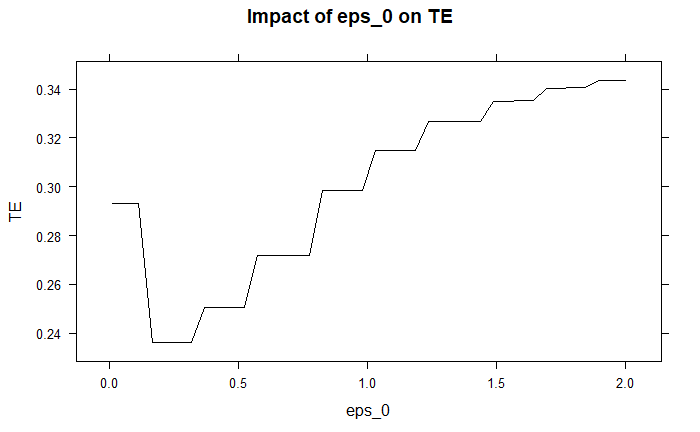

```r
pdp_FS1_T0_TE_QE_TE_5
```

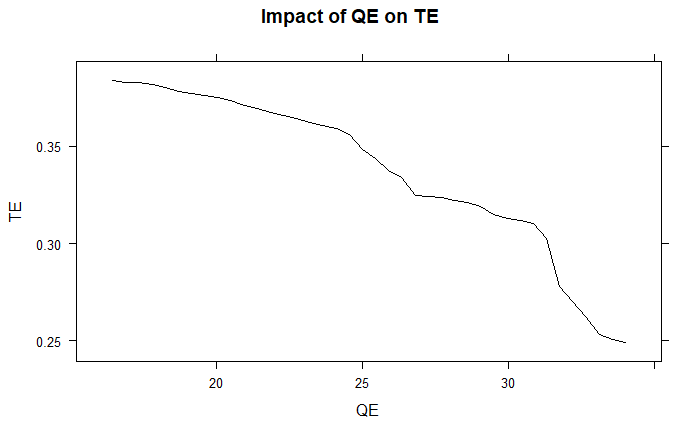

```r
pdp_FS1_T0_TE_QE_TE_6
```

```r
# eps_0 min values
subset(p_FS1_T0_TE_QE_TE_5,p_FS1_T0_TE_QE_TE_5$yhat==min(p_FS1_T0_TE_QE_TE_5$yhat))
```

|  | eps_0 | yhat |
| --- | --- | --- |
| 4 | 0.1630769 | 0.2360613 |
| 5 | 0.2141026 | 0.2360613 |

```r
# QE min values
subset(p_FS1_T0_TE_QE_TE_6,p_FS1_T0_TE_QE_TE_6$yhat==min(p_FS1_T0_TE_QE_TE_6$yhat))
```

|  | QE | yhat |
| --- | --- | --- |
| 40 | 33.99992 | 0.2488812 |

#Summary on the graphs TE was low when  
* Init proto : random  
* eps_0 : in the range of [0.1630,0.2141]  
* QE : when QE was high

# Analysis of QE and TE values

- Best values of QE and TE will be around mean value of TE (i.e yhat)
- Best low QE and TE were at approx 27 and 0.32 respectively

```r
mean(p_FS1_T0_TE_QE_TE_6$yhat)
```

```
[1] 0.3371357
```

```r
m_x <-mean(p_FS1_T0_TE_QE_TE_6$yhat)+0.02
m_y <-mean(p_FS1_T0_TE_QE_TE_6$yhat)-0.02
m_x
```

```
[1] 0.3571357
```

```r
m_y
```

```
[1] 0.3171357
```

```r
subset(p_FS1_T0_TE_QE_TE_6,p_FS1_T0_TE_QE_TE_6$yhat>m_y & p_FS1_T0_TE_QE_TE_6$yhat<m_x)
```

|  | QE | yhat |
| --- | --- | --- |
| 19 | 24.54083 | 0.3560160 |
| 20 | 24.99127 | 0.3484542 |
| 21 | 25.44170 | 0.3437929 |
| 22 | 25.89213 | 0.3376163 |
| 23 | 26.34256 | 0.3342426 |
| 24 | 26.79300 | 0.3245513 |
| 25 | 27.24343 | 0.3242334 |
| 26 | 27.69386 | 0.3235066 |
| 27 | 28.14429 | 0.3221633 |
| 28 | 28.59473 | 0.3212614 |

[output cut: 1 more lines]

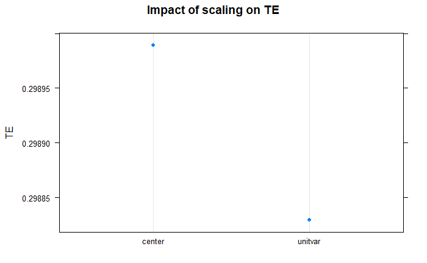

```r
p_FS1_T0_TE_QE_TE_7 <-partial(rf_model_target_TE, pred.var = c("scaling"), grid.resolution = 40)
p_FS1_T0_TE_QE_TE_8 <-partial(rf_model_target_TE, pred.var = c("Max_Itr"), grid.resolution = 40)
pdp_FS1_T0_TE_QE_TE_7<- plotPartial(p_FS1_T0_TE_QE_TE_7,ylab="TE", main="Impact of scaling on TE")
pdp_FS1_T0_TE_QE_TE_8<- plotPartial(p_FS1_T0_TE_QE_TE_8,ylab="TE", main="Impact of max itr on TE")
pdp_FS1_T0_TE_QE_TE_7
```

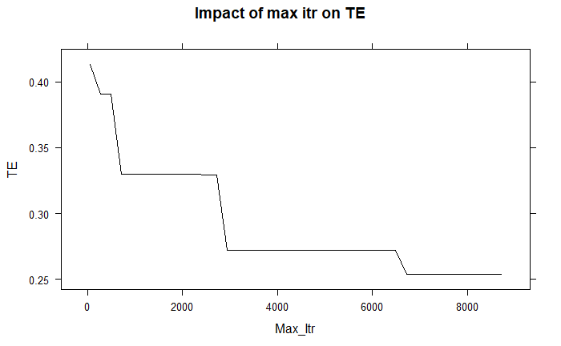

```r
pdp_FS1_T0_TE_QE_TE_8
```

```r
# Max itr values
subset(p_FS1_T0_TE_QE_TE_8,p_FS1_T0_TE_QE_TE_8$yhat==min(p_FS1_T0_TE_QE_TE_8$yhat))
```

|  | Max_Itr | yhat |
| --- | --- | --- |
| 31 | 6715 | 0.2534748 |
| 32 | 6937 | 0.2534748 |
| 33 | 7159 | 0.2534748 |
| 34 | 7381 | 0.2534748 |
| 35 | 7604 | 0.2534748 |
| 36 | 7826 | 0.2534748 |
| 37 | 8048 | 0.2534748 |
| 38 | 8270 | 0.2534748 |
| 39 | 8492 | 0.2534748 |
| 40 | 8715 | 0.2534748 |

#Summary on the graphs TE was low when  
* scaling : unitvar. Not big difference.  
* Max itr: in range [6715, 8715]

# Conclusion [individual predictors were observed ]:

TE was low when  
* Dimension was high. But difference is not that much.  
* Neigh function: guassian . Deciding factor  
* Distance: canberra and maximum had low values for TE. But difference is not much.  
* Init proto : random  
* eps_0 : in the range of [0.1630,0.2141]  
* QE : when QE was high  
* scaling : unitvar. Not big difference.  
* Max itr: in range [6715, 8715]

# Analysis of QE along with other hyperparameter

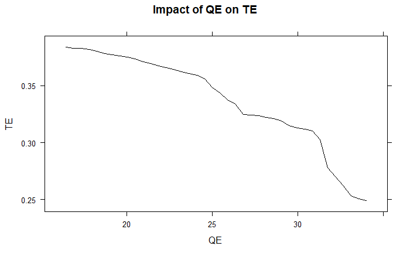

```r
p_FS1_T0_TE_QE_TE_12 <-partial(rf_model_target_TE, pred.var = c("QE") , grid.resolution = 40 )
p_FS1_T0_TE_QE_TE_13 <-partial(rf_model_target_TE, pred.var = c("QE","dimension") , grid.resolution = 40)
p_FS1_T0_TE_QE_TE_14 <-partial(rf_model_target_TE, pred.var = c("QE","init_proto") , grid.resolution = 40)
p_FS1_T0_TE_QE_TE_15 <-partial(rf_model_target_TE, pred.var = c("QE","eps_0") , grid.resolution = 40)
p_FS1_T0_TE_QE_TE_16 <-partial(rf_model_target_TE, pred.var = c("QE","scaling") , grid.resolution = 40)

pdp_FS1_T0_TE_QE_TE_12<- plotPartial(p_FS1_T0_TE_QE_TE_12,ylab="TE", main="Impact of QE on TE")
pdp_FS1_T0_TE_QE_TE_13<- plotPartial(p_FS1_T0_TE_QE_TE_13, main="Impact of QE and dimension on TE")
pdp_FS1_T0_TE_QE_TE_14<- plotPartial(p_FS1_T0_TE_QE_TE_14,ylab="TE", main="Impact of QE and init proto on TE")
pdp_FS1_T0_TE_QE_TE_15<- plotPartial(p_FS1_T0_TE_QE_TE_15, main="Impact of QE and eps_0 on TE")
pdp_FS1_T0_TE_QE_TE_16<- plotPartial(p_FS1_T0_TE_QE_TE_16,ylab="TE", main="Impact of QE and scaling on TE")

pdp_FS1_T0_TE_QE_TE_12
```

```r
pdp_FS1_T0_TE_QE_TE_13
```

[output not shown]

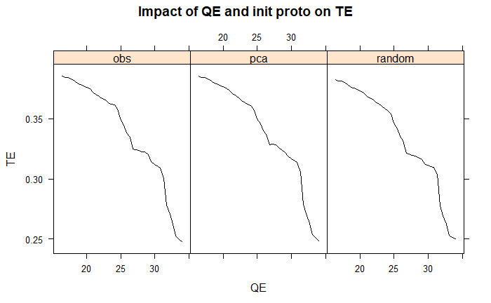

```r
pdp_FS1_T0_TE_QE_TE_14
```

```r
pdp_FS1_T0_TE_QE_TE_15
```

[output not shown]

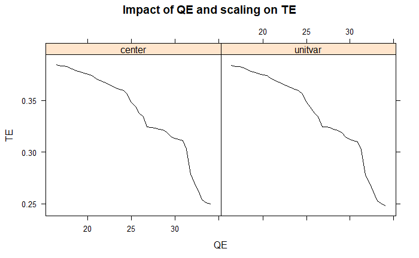

```r
pdp_FS1_T0_TE_QE_TE_16
```

# Summary on graphs

*Plot 1* : TE was very low when QE was high.

*PLot 3*: * similar trend for all values of QE and init proto.

*Plot 5* scaling : both have similar graph

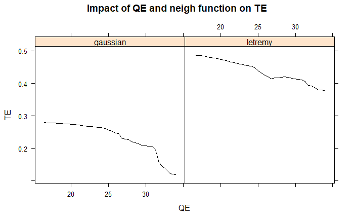

```r
p_FS1_T0_TE_QE_TE_17 <- partial(rf_model_target_TE, pred.var = c("QE","neigh_function") , grid.resolution = 40 )
p_FS1_T0_TE_QE_TE_18 <- partial(rf_model_target_TE, pred.var = c("QE","distance_func") , grid.resolution = 40 )
p_FS1_T0_TE_QE_TE_19 <- partial(rf_model_target_TE, pred.var = c("QE","Max_Itr") , grid.resolution = 40 )


pdp_FS1_T0_TE_QE_TE_17<- plotPartial(p_FS1_T0_TE_QE_TE_17,ylab="TE", main="Impact of QE and neigh function on TE")
pdp_FS1_T0_TE_QE_TE_18<- plotPartial(p_FS1_T0_TE_QE_TE_18,ylab="TE", main="Impact of QE and dist function on TE")
pdp_FS1_T0_TE_QE_TE_19<- plotPartial(p_FS1_T0_TE_QE_TE_19, main="Impact of QE and max itr on TE")

pdp_FS1_T0_TE_QE_TE_17
```

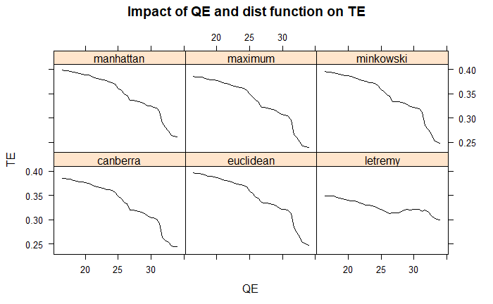

```r
pdp_FS1_T0_TE_QE_TE_18
```

```r
pdp_FS1_T0_TE_QE_TE_19
```

[output not shown]

# Multiple predictors

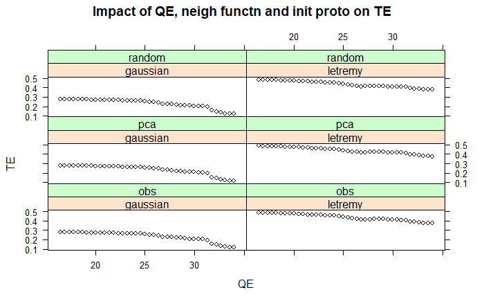

```r
p_FS1_T0_TE_QE_TE_9 <-partial(rf_model_target_TE, pred.var = c("QE","neigh_function","init_proto") , grid.resolution = 40 )
p_FS1_T0_TE_QE_TE_10 <-partial(rf_model_target_TE, pred.var = c("QE","scaling","init_proto"), grid.resolution = 60)
p_FS1_T0_TE_QE_TE_11 <-partial(rf_model_target_TE, pred.var = c("QE","distance_func","neigh_function"), grid.resolution = 60)


pdp_FS1_T0_TE_QE_TE_9<- plotPartial(p_FS1_T0_TE_QE_TE_9,ylab="TE", main= "Impact of QE, neigh functn and init proto on TE")
pdp_FS1_T0_TE_QE_TE_10<- plotPartial(p_FS1_T0_TE_QE_TE_10,ylab="TE", main= "Impact of QE, scaling and init proto on TE")
pdp_FS1_T0_TE_QE_TE_11<- plotPartial(p_FS1_T0_TE_QE_TE_11,ylab="TE", main= "Impact of QE,dist func and neigh functn  on TE")


pdp_FS1_T0_TE_QE_TE_9
```

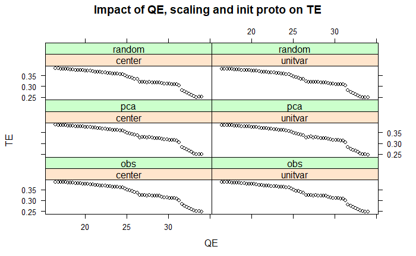

```r
pdp_FS1_T0_TE_QE_TE_10
```

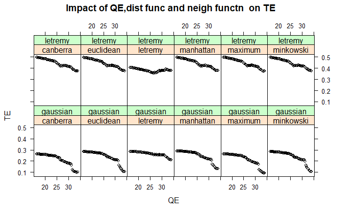

```r
pdp_FS1_T0_TE_QE_TE_11
```

# Summary on the graphs

*Plot 1* : * TE was low when guassian neigh function was used with any init proto type.

*Plot 2* : * similar trends.

*Plot 3* : * clearly guassian neigh function has all lower trends for TE  
Note : During hyper parameter optimization below error occured.  
dist.type value replaced to ‘euclidean’ for Gaussian radius

```
        ('letremy' is not allowed) </br>
```

but in dataframe final values were captured as guassian and letremy

*PDP analysis:* * Best low QE and TE were approx 27 and 0.32 respectively.  
* As pdp analysis is based on average results. low best QE and TE will be more or less than above predicted values.  
*1)* Increase the dimension to reduce QE. use Letremy for low values of QE  
*2)* Use guassian to reduce TE. also max itr and eps have impact on TE

Previous results for comparision  
# Conclusion on QE (TE was not considered during pdp check) * QE was significantly low with below features  
dimension: higher dimension  
Radius type : Letremy  
Distance type: Letremy  
Init proto : pca and obs  
eps_0 :QE decreases with increase eps_0 values  
Scaling : unitvar  
Max itr: more than 6200 had low QE throughout

# Conclusion for TE ( QE was not considered during pdp check)

# SOM Brero model training

```r
h_dimension_T <- c(16)# 6
h_radius.type_T <- c("letremy")
h_dist.type_T <- c("letremy") # eucli
h_maxit_T <-c(8715)#4000
h_eps_0_T <- c(0.2311111) #0.2311111
h_init.proto_T <- c("obs")
h_scaling_T <- c("unitvar") # center
```

```r
FS1_T0_Brero <- trainSOM(x.data = scaled_data, nb.save=2,
                              dimension = c(h_dimension_T,h_dimension_T),
                              radius.type=as.character(h_radius.type_T),
                              dist.type=as.character(h_dist.type_T),
                              maxit=h_maxit_T,
                              eps0=h_eps_0_T,
                              init.proto=as.character(h_init.proto_T),
                              scaling =as.character(h_scaling_T))
```

# Quality

```r
quality(FS1_T0_Brero, quality.type="all")
```

```
$topographic
[1] 0.1394148

$quantization
[1] 21.5103
```

# Some results from SOM Brero model training:

- TE for both neighborhood function was in approximately 0.12 to 0.15
- QE
  1. with Gaussian: was in range of 30
  2. with letremy : was in range of 20

```r
dim(model_df_FS1_T0_TE_QE_lower)
```

```
[1] 19715     9
```

```r
max(model_df_FS1_T0_TE_QE_lower$QE)
```

```
[1] 33.99992
```

[output not shown]

```r
df_dim16[df_dim16$QE==min(df_dim16$QE),]

df_dim16[df_dim16$TE==min(df_dim16$TE),]
```

|  | dimension | neigh_function | distance_func | init_proto | eps_0 | TE | QE | scaling | Max_Itr |
| --- | --- | --- | --- | --- | --- | --- | --- | --- | --- |
| 11170 | 16 | gaussian | euclidean | pca | 1.778889 | 0.03614458 | 33.17349 | unitvar | 4500 |

# Max iteration

- Higher values of max iteration checked.
- Results stored in csv.

```r
temp_h_maxit_T <- round(seq.int(from=6000, to=100000, length = 60))
```

```r
df_max_itr <- read.csv("D:\\DKE\\Thesis_related\\Implementation\\Hyper_tuning_results\\Fs1_Max_Itr_rangeCheck.csv")
```

```r
df_max_itr[df_max_itr$TE== min(df_max_itr$TE),]
```

|  | dimension | neigh_function | distance_func | init_proto | eps_0 | TE | QE | scaling | Empty_Neurons | Max_Itr |
| --- | --- | --- | --- | --- | --- | --- | --- | --- | --- | --- |
| 49 | 16 | letremy | letremy | obs | 0.2311111 | 0.07917384 | 21.51263 | unitvar | 6 | 82475 |

```r
df_max_itr[df_max_itr$QE== min(df_max_itr$QE),]
```

|  | dimension | neigh_function | distance_func | init_proto | eps_0 | TE | QE | scaling | Empty_Neurons | Max_Itr |
| --- | --- | --- | --- | --- | --- | --- | --- | --- | --- | --- |
| 12 | 16 | letremy | letremy | obs | 0.2311111 | 0.1049914 | 20.84685 | unitvar | 9 | 23525 |

```r
rf_max_itr_target_TE <- randomForest(TE ~ ., data = df_max_itr)
```

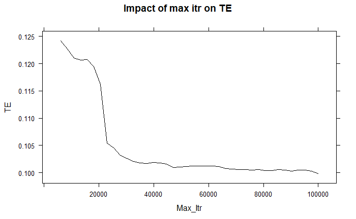

```r
p_mx_itr_1 <-pdp::partial(rf_max_itr_target_TE, pred.var = c("Max_Itr"), grid.resolution = 40)

pdp_mx_itr_1<- plotPartial(p_mx_itr_1,ylab="TE", main="Impact of max itr on TE")

pdp_mx_itr_1
```

```r
subset(p_mx_itr_1,p_mx_itr_1$yhat==min(p_mx_itr_1$yhat))
```

|  | Max_Itr | yhat |
| --- | --- | --- |
| 40 | 1e+05 | 0.09978929 |

```r
p_mx_itr_2 <-pdp::partial(rf_model_target_TE, pred.var = c("QE","Max_Itr"), grid.resolution = 60)



pdp_mx_itr_2<- plotPartial(p_mx_itr_2,ylab="TE", main= "Impact of QE and max itr  on TE")
```

[output not shown]

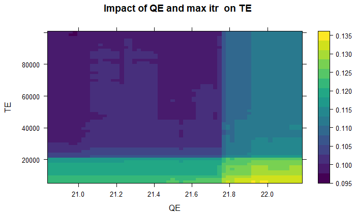

```r
p_mx_itr_2 <- pdp::partial(rf_max_itr_target_TE, pred.var = c("QE","Max_Itr"), grid.resolution = 60)


pdp_mx_itr_2<- plotPartial(p_mx_itr_2,ylab="TE", main= "Impact of QE and max itr  on TE")


pdp_mx_itr_2
```

```r
subset(p_mx_itr_2,p_mx_itr_2$yhat==min(p_mx_itr_2$yhat))
```

|  | QE | Max_Itr | yhat |
| --- | --- | --- | --- |
| 3487 | 20.98173 | 98406.78 | 0.09750071 |

# Conclusion:

- Best values of QE and TE can be obtained with mar iteration in the range of 98406.

**References**

Delgado, Soledad, Clara Higuera, Jorge Calle-Espinosa, Federico Morán, and Francisco Montero. 2017. “A SOM Prototype-Based Cluster Analysis Methodology.”

Liu, Yonggang, Robert H. Suleman, and Christopher N.K. Mooers. 2006. “Performance Evaluation of the Self-Organizing Map for Feature Extraction.”

Polzlbauer, Georg. n.d. “Survey and Comparison of Quality Measures for Self-Organizing Maps.”

Villa Vialaneix, Nathalie. n.d. “Stochastic Self Organizing Map Variants with the R Package SOMbrero.”